# TP analyse reproductible

Bineta FAYE

2024-11-12

Dataset Titanic de carData

## Initialisation du Projet sur GitHub et Clonage Local: fait!

## Création d’un Rapport d’Analyse dans un Document RMarkdown

```r
library(carData)
df<-TitanicSurvival
summary(df)
```

```
##  survived      sex           age          passengerClass
##  no :809   female:466   Min.   : 0.1667   1st:323
##  yes:500   male  :843   1st Qu.:21.0000   2nd:277
##                         Median :28.0000   3rd:709
##                         Mean   :29.8811
##                         3rd Qu.:39.0000
##                         Max.   :80.0000
##                         NA's   :263
```

**Je vous laisse le soin de décrire les données, vous pouvez chercher la description des données dans “Help” du package**

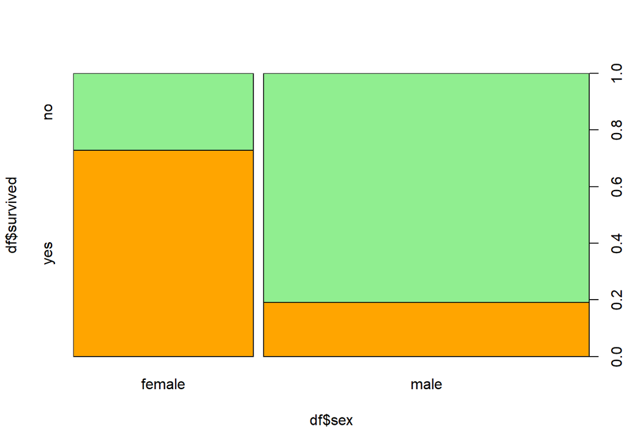

```r
plot(df$survived~df$sex, col=c("orange","lightgreen"))
```

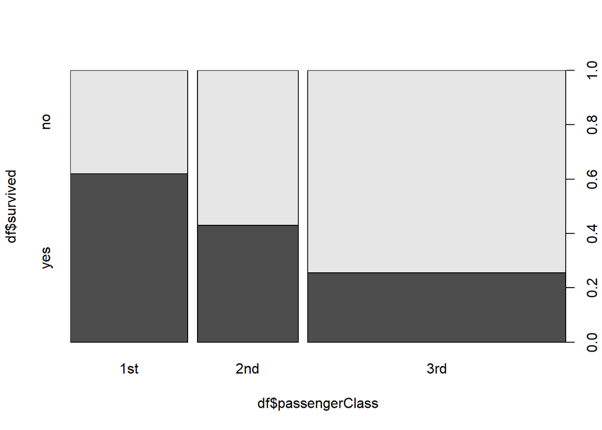

```r
plot(df$survived~df$passengerClass)
```

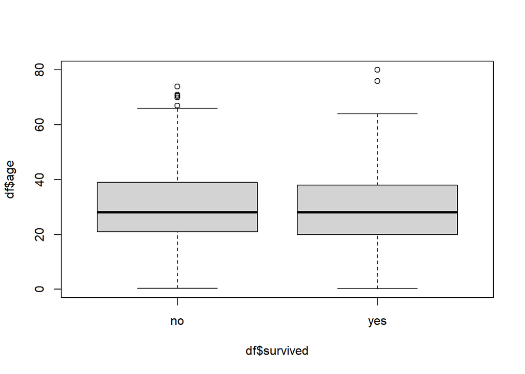

```r
plot(df$age~df$survived)
```

#### Tracés avec ggplot2

Documentation:https://github.com/rstudio/cheatsheets/blob/main/data-visualization.pdf

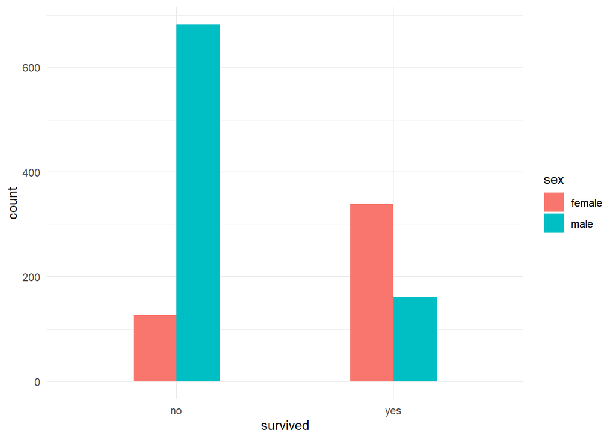

```r
library(ggplot2)
ggplot(df, aes(survived,fill=sex)) +
  geom_bar(position = "dodge",width = 0.4)+
  theme_minimal()
```

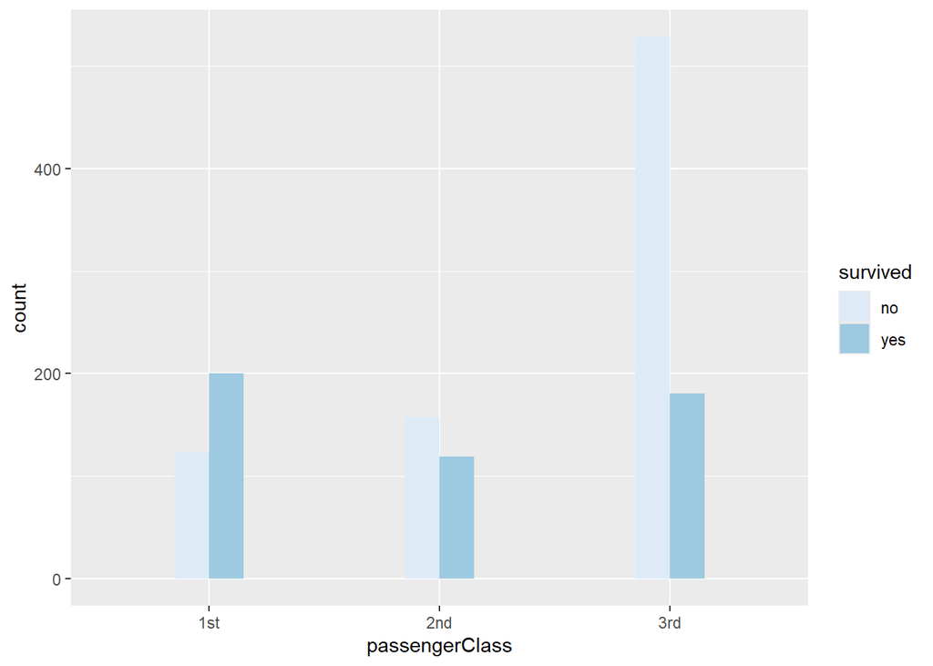

```r
ggplot(df, aes(passengerClass,fill=survived)) +
  geom_bar(position = "dodge",width = 0.3)+
  scale_fill_brewer(palette = "Blues")
```

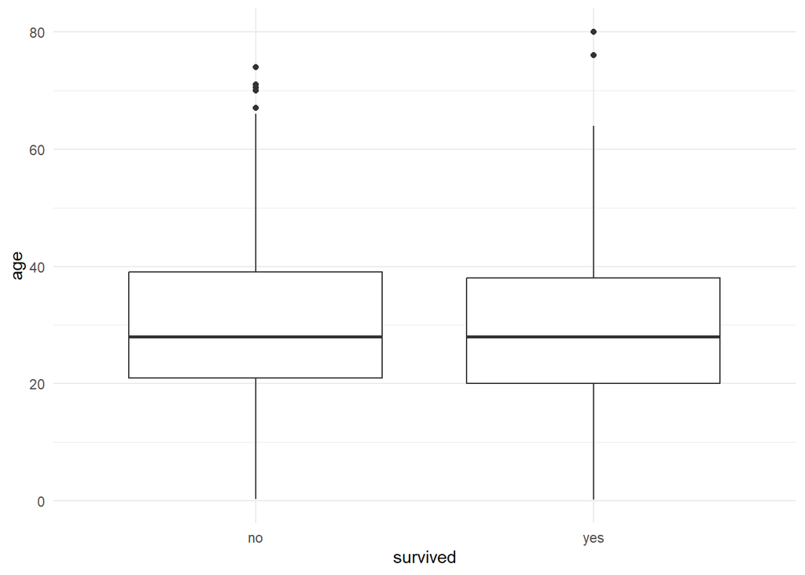

```r
ggplot(df, aes(survived,age)) +
  geom_boxplot() +
  theme_minimal()
```

```r
y<-as.numeric(df$survived)-1
summary(glm(y~age+sex+passengerClass , data=df,family = binomial(link = "logit")))
```

```
##
## Call:
## glm(formula = y ~ age + sex + passengerClass, family = binomial(link = "logit"),
##     data = df)
##
## Coefficients:
##                    Estimate Std. Error z value Pr(>|z|)
## (Intercept)        3.522074   0.326702  10.781  < 2e-16 ***
## age               -0.034393   0.006331  -5.433 5.56e-08 ***
## sexmale           -2.497845   0.166037 -15.044  < 2e-16 ***
## passengerClass2nd -1.280570   0.225538  -5.678 1.36e-08 ***
## passengerClass3rd -2.289661   0.225802 -10.140  < 2e-16 ***
## ---
## Signif. codes:  0 '***' 0.001 '**' 0.01 '*' 0.05 '.' 0.1 ' ' 1
##
## (Dispersion parameter for binomial family taken to be 1)
##
##     Null deviance: 1414.62  on 1045  degrees of freedom
## Residual deviance:  982.45  on 1041  degrees of freedom
##   (263 observations effacées parce que manquantes)
## AIC: 992.45
##
## Number of Fisher Scoring iterations: 4
```

**Age (-0.034393) : Ce coefficient est négatif, ce qui indique que l’âge a un effet défavorable sur la survie : à chaque année supplémentaire, le logit de la probabilité de survie diminue d’environ 0.0344, soit une réduction de la probabilité de survie. Ce coefficient est significatif (p < 0.001).**

**Sexe masculin (sexmale = -2.497845) : Ce coefficient négatif indique que le fait d’être de sexe masculin réduit considérablement la probabilité de survie par rapport au sexe féminin, qui est la catégorie de référence. L’effet est très significatif (p < 0.001), et il semble que les hommes aient eu une probabilité de survie bien plus faible que les femmes dans ce contexte.**

**Classe de passager :**

**Classe 2nd (passengerClass2nd = -1.280570) : Le coefficient est négatif, ce qui montre que les passagers de deuxième classe avaient une probabilité de survie plus faible que ceux de première classe (catégorie de référence). Cet effet est significatif (p < 0.001).**

**Classe 3rd (passengerClass3rd = -2.289661) : Le coefficient négatif et encore plus important montre que les passagers de troisième classe avaient une probabilité de survie encore plus faible que ceux de première classe. Ce résultat est également très significatif (p < 0.001)**

## Création d’un Package R avec des fonctions d’Analyse

- devtools::create(“TitanicPckg”)
- creation du fichier taux.R avec les fonctions
- documentation: en-tete + save et devtools::document(“TitanicPckg”)
- devtools::build(“TitanicPckg”)
- devtools::install(“TitanicPckg”)

```r
#### TP Titanic packages

#' taux de survie en fonction du sex
#'
#' @param data data frame
#' @return A list
#' @examples
#' taux_survie_sex(df)
#' @export

taux_survie_sex <- function(data) {
  library(dplyr)
  return(data %>%
    group_by(sex) %>%
    summarize(TauxSurvie = sum(survived == "yes") / n()))
}




######################
######################

#' taux de survie en fonction de la classe
#'
#' @author Bineta FAYE
#' @param data data frame
#' @return A list
#' @examples
#' taux_survie_class(df)
#' @export

taux_survie_class <- function(data) {
  library(dplyr)
  return(data %>%
           group_by(passengerClass) %>%
           summarize(TauxSurvie = sum(survived == "yes") / n()))
}
```

### Utilisation des fonctions de mon package

```r
library(TitanicPckg)
taux_survie_sex(df)
```

```
## # A tibble: 2 × 2
##   sex    TauxSurvie
##   <fct>       <dbl>
## 1 female      0.727
## 2 male        0.191
```

```r
TitanicPckg::taux_survie_class(df)
```

```
## # A tibble: 3 × 2
##   passengerClass TauxSurvie
##   <fct>               <dbl>
## 1 1st                 0.619
## 2 2nd                 0.430
## 3 3rd                 0.255
```

## Rapport Final et Partage

- git status
- git add -A
- git commit -m “rapport final”
- git push